# UTS2024_IF540L_Kelas_H_Kelompok_7

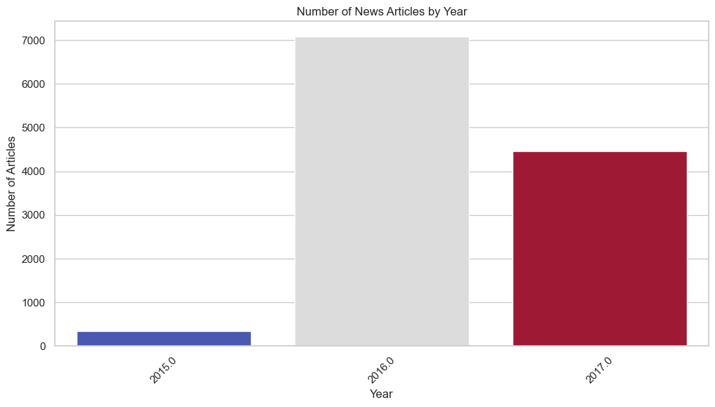

```python
# Convert 'date' to datetime
df['date'] = pd.to_datetime(df['date'], errors='coerce')

# Extract the year from the date
df['year'] = df['date'].dt.year

# Plotting for number of articles by year
plt.figure(figsize=(12, 6))
sns.countplot(x='year', hue='year', data=df, palette='coolwarm',
              order=df['year'].dropna().sort_values().unique(), legend=False)
plt.xlabel('Year')
plt.ylabel('Number of Articles')
plt.title('Number of News Articles by Year')
plt.xticks(rotation=45)
plt.show()
```

### Preprocessing

##### Chart disini menunjukkan distribusi artikel selama beberapa tahun. Bagan ini menyoroti bahwa sebagian besar kumpulan data berasal dari tahun 2016, diikuti oleh tahun 2017. Memahami distribusi temporal artikel membantu menentukan apakah ada peristiwa atau periode tertentu yang memiliki lebih banyak liputan berita, yang dapat memengaruhi distribusi Fake vs. True.

```python
import pandas as pd
import re
import string
from sklearn.model_selection import train_test_split
from sklearn.preprocessing import LabelEncoder, StandardScaler
from sklearn.feature_extraction.text import TfidfVectorizer

# Step 1 (Pretty optional): Handling Missing Values (Why not right? better safe than sorry)
# Drop rows with missing values in the important columns
df_cleaned = df.dropna(subset=['text', 'label', 'date'])

# Step 2: Text Cleaning
# Function to clean the text: remove URLs, special characters, etc.
def clean_text(text):
    text = re.sub('\[.*?\]','',text)
    text = re.sub("\\W"," ",text)
    text = re.sub('https?://\S+|www\.\S+','',text)
    text = re.sub('<.*?>+',b'',text)
    text = re.sub('[%s]' % re.escape(string.punctuation),'',text)
    text = re.sub('\w*\d\w*','',text)
    return text.strip().lower()

# Apply the text cleaning function to the 'text' column
df_cleaned.loc[:, 'text'] = df_cleaned['text'].apply(clean_text)

# Step 3: Label Encoding
# Convert labels into numerical values (fake -> 0, real -> 1)
label_encoder = LabelEncoder()
df_cleaned.loc[:, 'label'] = label_encoder.fit_transform(df_cleaned['label'])

# Step 4: Feature Engineering (TF-IDF)
# Convert the text column into numerical features using TF-IDF vectorization
tfidf_vectorizer = TfidfVectorizer(max_features=5000)  # Limiting to top 5000 features to reduce dimensionality
X_tfidf = tfidf_vectorizer.fit_transform(df_cleaned['text'])

# Step 5: Normalization
# Convert the TF-IDF matrix to an array for scaling
X_tfidf_array = X_tfidf.toarray()

# Apply StandardScaler to scale features
scaler = StandardScaler()
X_scaled = scaler.fit_transform(X_tfidf_array)

# Step 6: Splitting the Dataset
# Define features (X) and target labels (y)
X = X_scaled
y = df_cleaned['label']

# Split the data into training (80%) and test (20%) sets
X_train, X_test, y_train, y_test = train_test_split(X, y, test_size=0.2, random_state=42)

# Display the sizes of training and test sets
print("Training set size:", X_train.shape)
print("Test set size:", X_test.shape)
```

```
Training set size: (9494, 5000)
Test set size: (2374, 5000)
```

##### Data Split tampaknya wajar, dengan rasio sekitar 80-20 antara set pelatihan dan pengujian. Ini menunjukkan bahwa ada cukup data untuk melatih model dan mengevaluasi kinerjanya dengan benar.